# Chap9

Kazu

9/27/2019

# Quad approximation does not work with non Gausian distribution… (by J)

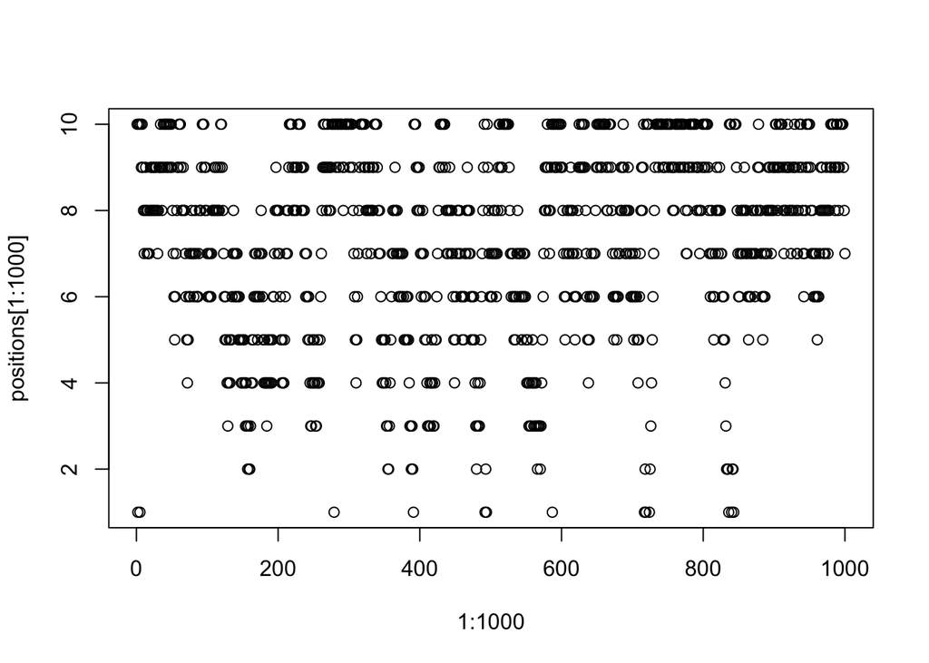

```r
num_weeks <- 1e5
positions <- rep(0,num_weeks)
current <- 10
for ( i in 1:num_weeks ) {
  # record current position
  positions[i] <- current
  # flip coin to generate proposal
  proposal <- current + sample( c(-1,1) , size=1 )
  # now make sure he loops around the archipelago
  if ( proposal < 1 ) proposal <- 10
  if ( proposal > 10 ) proposal <- 1
  # move?
  prob_move <- proposal/current
  current <- ifelse( runif(1) < prob_move , proposal , current )
}
plot(x=1:1000, y=positions[1:1000])
```

## R code 9.2

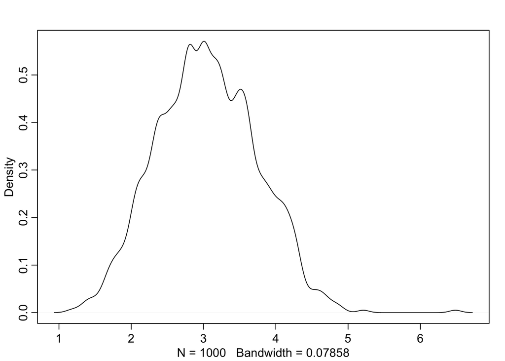

```r
D <- 10
T <- 1e3
Y <- rmvnorm(T,rep(0,D),diag(D))
rad_dist <- function( Y ) sqrt( sum(Y^2) )
Rd <- sapply( 1:T , function(i) rad_dist( Y[i,] ) )
dens( Rd )
```

## R code 9.3

```r
# U needs to return neg-log-probability
myU4 <- function( q , a=0 , b=1 , k=0 , d=1 ) {
  muy <- q[1]
  mux <- q[2]
  U <- sum( dnorm(y,muy,1,log=TRUE) ) + sum( dnorm(x,mux,1,log=TRUE) ) +
    dnorm(muy,a,b,log=TRUE) + dnorm(mux,k,d,log=TRUE)
  return( -U )
}
```

## R code 9.4

```r
# gradient function
# need vector of partial derivatives of U with respect to vector q
myU_grad4 <- function( q , a=0 , b=1 , k=0 , d=1 ) {
  muy <- q[1]
  mux <- q[2]
  G1 <- sum( y - muy ) + (a - muy)/b^2 #dU/dmuy
  G2 <- sum( x - mux ) + (k - mux)/d^2 #dU/dmuy
  return( c( -G1 , -G2 ) ) # negative bc energy is neg-log-prob
}
# test data
set.seed(7)
y <- rnorm(50)
x <- rnorm(50)
x <- as.numeric(scale(x))
y <- as.numeric(scale(y))
```

## R code 9.5

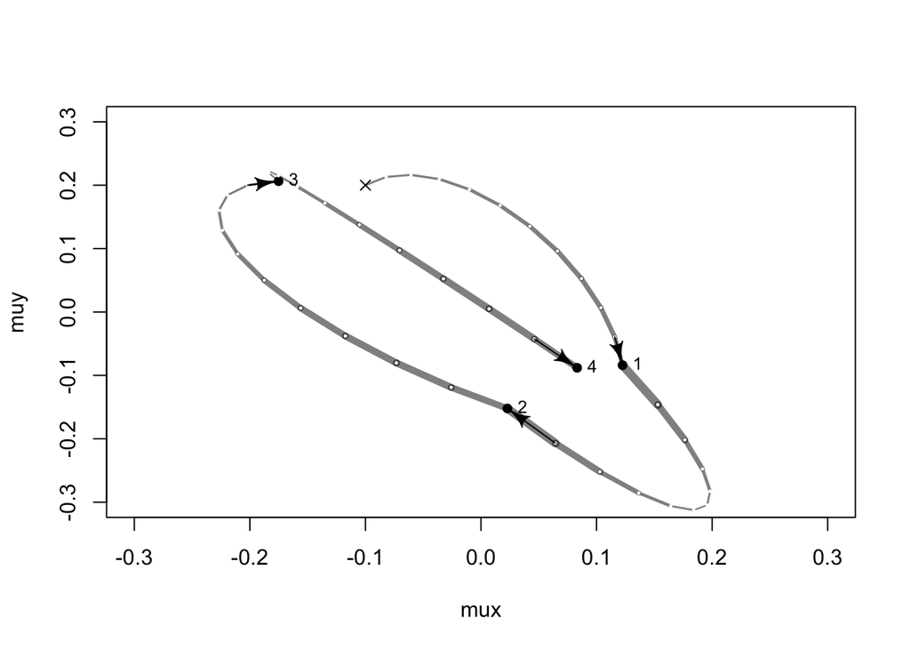

```r
library(shape) # for fancy arrows
Q <- list()
Q$q <- c(-0.1,0.2)
pr <- 0.3
plot( NULL , ylab="muy" , xlab="mux" , xlim=c(-pr,pr) , ylim=c(-pr,pr) )
step <- 0.03
L <- 11 # 0.03/28 for U-turns --- 11 for working example
n_samples <- 4
path_col <- col.alpha("black",0.5)
points( Q$q[1] , Q$q[2] , pch=4 , col="black" )
for ( i in 1:n_samples ) {
  Q <- HMC2( myU4 , myU_grad4 , step , L , Q$q )
  if ( n_samples < 10 ) {
    for ( j in 1:L ) {
      K0 <- sum(Q$ptraj[j,]^2)/2 # kinetic energy
      lines( Q$traj[j:(j+1),1] , Q$traj[j:(j+1),2] , col=path_col , lwd=1+2*K0 )
    }
    points( Q$traj[1:L+1,] , pch=16 , col="white" , cex=0.35 )
    Arrows( Q$traj[L,1] , Q$traj[L,2] , Q$traj[L+1,1] , Q$traj[L+1,2] ,
            arr.length=0.35 , arr.adj = 0.7 )
    text( Q$traj[L+1,1] , Q$traj[L+1,2] , i , cex=0.8 , pos=4 , offset=0.4 )
  }
  points( Q$traj[L+1,1] , Q$traj[L+1,2] , pch=ifelse( Q$accept==1 , 16 , 1 ) ,
          col=ifelse( abs(Q$dH)>0.1 , "red" , "black" ) )
}
```

## R code 9.6

```r
HMC2 <- function (U, grad_U, epsilon, L, current_q) {
  q = current_q
  p = rnorm(length(q),0,1) # random flick - p is momentum.
  current_p = p
  # Make a half step for momentum at the beginning
  p = p - epsilon * grad_U(q) / 2
  # initialize bookkeeping - saves trajectory
  qtraj <- matrix(NA,nrow=L+1,ncol=length(q))
  ptraj <- qtraj
  qtraj[1,] <- current_q
  ptraj[1,] <- p

  ## R code 9.7
  # Alternate full steps for position and momentum
  for ( i in 1:L ) {
    q = q + epsilon * p # Full step for the position
    # Make a full step for the momentum, except at end of trajectory
    if ( i!=L ) {
      p = p - epsilon * grad_U(q)
      ptraj[i+1,] <- p
    }
    qtraj[i+1,] <- q
  }
  ## R code 9.8
  # Make a half step for momentum at the end
  p = p - epsilon * grad_U(q) / 2
  ptraj[L+1,] <- p
  # Negate momentum at end of trajectory to make the proposal symmetric
  p = -p
  # Evaluate potential and kinetic energies at start and end of trajectory
  current_U = U(current_q)
  current_K = sum(current_p^2) / 2
  proposed_U = U(q)
  proposed_K = sum(p^2) / 2
  # Accept or reject the state at end of trajectory, returning either
  # the position at the end of the trajectory or the initial position
  accept <- 0
  if (runif(1) < exp(current_U-proposed_U+current_K-proposed_K)) {
    new_q <- q  # accept
    accept <- 1
  } else new_q <- current_q  # reject
  return(list( q=new_q, traj=qtraj, ptraj=ptraj, accept=accept ))
}
```

# 9.4. EasyHMC:ulam

## the terrain ruggedness example from Chapter 7. This code will load the data and reduce it down to cases (nations) that have the outcome variable of interest:

## R code 9.9

```r
library(rethinking)
data(rugged)
d <- rugged
d$log_gdp <- log(d$rgdppc_2000) # log GDP
# extract countries with GDP data
dd <- d[ complete.cases(d$rgdppc_2000) , ]
# rescale variables
dd$log_gdp_std <- dd$log_gdp / mean(dd$log_gdp)
dd$rugged_std <- dd$rugged / max(dd$rugged)
# make variable to index Africa (1) or not (2) (pg 249)
dd$cid <- ifelse( dd$cont_africa==1 , 1 , 2 )
```

## R code 9.10 (the old way)

```r
m8.5 <- quap(
  alist(
    log_gdp_std ~ dnorm( mu , sigma ) ,
    mu <- a[cid] + b[cid]*( rugged_std - 0.215 ) ,
    a[cid] ~ dnorm( 1 , 0.1 ) ,
    b[cid] ~ dnorm( 0 , 0.3 ) ,
    sigma ~ dexp( 1 )
  ) ,
  data=dd )
precis( m8.5 , depth=2 )
```

```
##             mean          sd        5.5%       94.5%
## a[1]   0.8865640 0.015674552  0.86151302  0.91161495
## a[2]   1.0505666 0.009935872  1.03468714  1.06644602
## b[1]   0.1324981 0.074199237  0.01391344  0.25108286
## b[2]  -0.1426057 0.054745410 -0.23009945 -0.05511197
## sigma  0.1094859 0.005934188  0.10000194  0.11896990
```

## R code 9.11

```r
dat_slim <- list(
  log_gdp_std = dd$log_gdp_std,
  rugged_std = dd$rugged_std,
  cid = as.integer( dd$cid )
)
str(dat_slim)
```

```
## List of 3
##  $ log_gdp_std: num [1:170] 0.88 0.965 1.166 1.104 0.915 ...
##  $ rugged_std : num [1:170] 0.138 0.553 0.124 0.125 0.433 ...
##  $ cid        : int [1:170] 1 2 2 2 2 2 2 2 2 1 ...
```

# 9.4.2. Sampling from the posterior

## R code 9.12

```r
m9.1 <- ulam(
  alist(
    log_gdp_std ~ dnorm( mu , sigma ) ,
    mu <- a[cid] + b[cid]*( rugged_std - 0.215 ) ,
    a[cid] ~ dnorm( 1 , 0.1 ) ,
    b[cid] ~ dnorm( 0 , 0.3 ) ,
    sigma ~ dexp(1)
  ) ,
  data=dat_slim , chains=1 )
```

## R code 9.13

```r
precis( m9.1 , depth=2 )
```

```
##             mean          sd        5.5%       94.5%     n_eff      Rhat
## a[1]   0.8856304 0.016135936  0.86090235  0.91030609  806.0820 0.9987430
## a[2]   1.0508378 0.009971161  1.03501948  1.06628425  852.5390 0.9982515
## b[1]   0.1282220 0.068979985  0.02276656  0.24283156 1168.7511 1.0028849
## b[2]  -0.1424442 0.054903299 -0.23611690 -0.05588177  634.8723 1.0024187
## sigma  0.1115647 0.006134172  0.10232762  0.12162977  560.4679 1.0003481
```

# 9.4.3. Samplingagain,inparallel.

## R code 9.14

```r
m9.1 <- ulam(
  alist(
    log_gdp_std ~ dnorm( mu , sigma ) ,
    mu <- a[cid] + b[cid]*( rugged_std - 0.215 ) ,
    a[cid] ~ dnorm( 1 , 0.1 ) ,
    b[cid] ~ dnorm( 0 , 0.3 ) ,
    sigma ~ dexp( 1 )
  ) ,
  data=dat_slim , chains=4 , cores=2 , iter=1000 )
```

```
## recompiling to avoid crashing R session
```

## R code 9.15

```r
show( m9.1 )
```

```
## Hamiltonian Monte Carlo approximation
## 2000 samples from 4 chains
##
## Sampling durations (seconds):
##         warmup sample total
## chain:1   0.07   0.04  0.11
## chain:2   0.06   0.04  0.10
## chain:3   0.08   0.05  0.12
## chain:4   0.07   0.05  0.12
##
## Formula:
## log_gdp_std ~ dnorm(mu, sigma)
## mu <- a[cid] + b[cid] * (rugged_std - 0.215)
## a[cid] ~ dnorm(1, 0.1)
## b[cid] ~ dnorm(0, 0.3)
## sigma ~ dexp(1)
```

## R code 9.16

```r
precis( m9.1 , 2 )
```

```
##             mean          sd         5.5%       94.5%    n_eff      Rhat
## a[1]   0.8867426 0.016196232  0.861266785  0.91280007 2828.427 0.9991543
## a[2]   1.0504301 0.009666239  1.034542266  1.06609864 3700.411 1.0006467
## b[1]   0.1335807 0.078235453  0.005115089  0.25812597 2601.253 1.0014678
## b[2]  -0.1413284 0.057254602 -0.235548822 -0.05065783 2625.489 0.9996354
## sigma  0.1115353 0.006137684  0.102428831  0.12192061 2384.926 0.9992556
```

# 9.4.4. Visualization

## R code 9.17

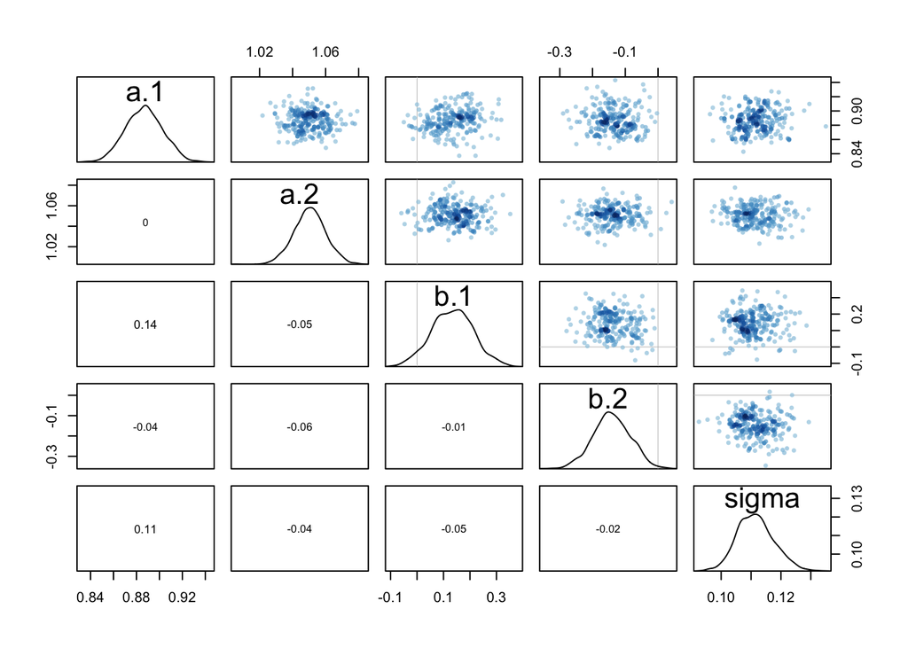

```r
pairs( m9.1 )
```

# 9.4.5. Checking the chain. ## R code 9.18

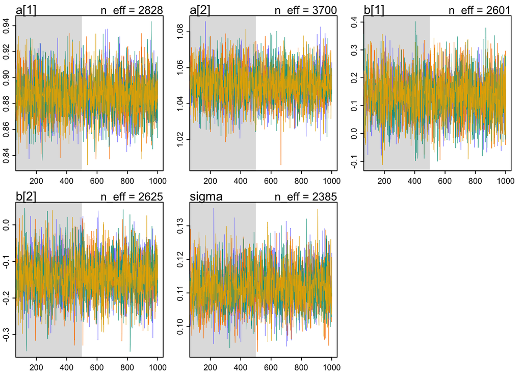

```r
traceplot( m9.1 )
```

## R code 9.19

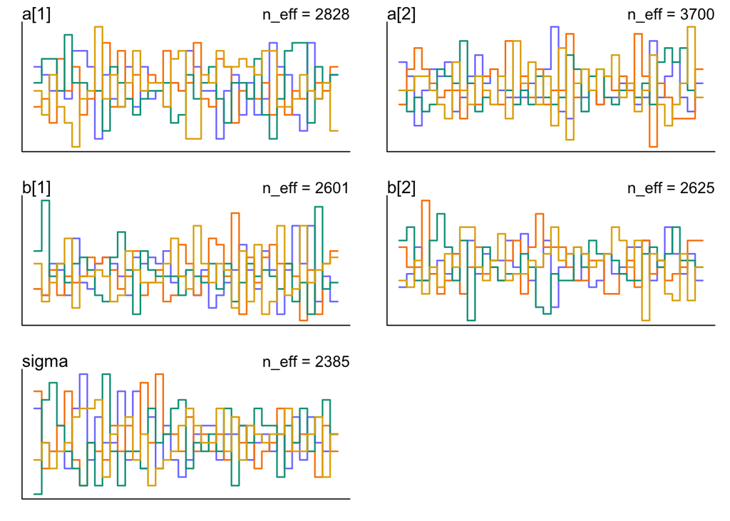

```r
trankplot( m9.1 , n_cols=2 )
```

# 9.7 Practice

## 8E3. Which sort of parameters can Hamiltonian Monte Carlo not handle? Can you explain why?

## 8M1. Re-estimate the terrain ruggedness model from the chapter,but now using a uniform prior and an exponential prior for the standard deviation, sigma. The uniform prior should be dunif(0,10) and the exponential should be dexp(1). Do the different priors have any detectible influence on the posterior distribution?

# 9.4.2. Sampling from the posterior

## R code 9.12

```r
# uniform prior for standar deviation
m9.1.sigma.unif <- ulam(
  alist(
    log_gdp_std ~ dnorm( mu , sigma ) ,
    mu <- a[cid] + b[cid]*( rugged_std - 0.215 ) ,
    a[cid] ~ dnorm( 1 , 0.1 ) ,
    b[cid] ~ dnorm( 0 , 0.3 ) ,
    sigma ~ dunif(0,10) # uniform prior
  ) ,
  data=dat_slim , chains=2,cores=2 ) # try chains 2 and cores 2
# exponential for standar deviation
m9.1.sigma.expo <- ulam(
  alist(
    log_gdp_std ~ dnorm( mu , sigma ) ,
    mu <- a[cid] + b[cid]*( rugged_std - 0.215 ) ,
    a[cid] ~ dnorm( 1 , 0.1 ) ,
    b[cid] ~ dnorm( 0 , 0.3 ) ,
    sigma ~ dexp(1) # an exponential prior
  ) ,
  data=dat_slim , chains=2, cores=2 )
```

```
## recompiling to avoid crashing R session
```

# posterior

```r
precis( m9.1.sigma.unif , depth=2 )
```

```
##             mean          sd         5.5%       94.5%    n_eff      Rhat
## a[1]   0.8868183 0.015957778  0.860132351  0.91163206 1161.996 1.0000029
## a[2]   1.0507080 0.009814728  1.035409208  1.06646307 1161.517 1.0000700
## b[1]   0.1318634 0.077709392  0.008303062  0.25452711 1248.291 0.9999272
## b[2]  -0.1434161 0.056626131 -0.237263121 -0.04962662 1709.644 0.9996944
## sigma  0.1117612 0.006385925  0.101755685  0.12207813 1626.221 0.9988239
```

```r
precis( m9.1.sigma.expo , depth=2 )
```

```
##             mean          sd         5.5%       94.5%    n_eff      Rhat
## a[1]   0.8861849 0.016115860  0.860851892  0.91198600 1590.612 0.9984785
## a[2]   1.0509258 0.009978057  1.034974416  1.06678642 1319.625 0.9987775
## b[1]   0.1305530 0.076584494  0.007185408  0.25268151 1163.748 0.9994244
## b[2]  -0.1435835 0.059122209 -0.238247697 -0.05156598 1205.701 0.9988154
## sigma  0.1116063 0.005910545  0.102538213  0.12167770 1125.975 0.9991012
```

```r
rethinking::compare(m9.1.sigma.unif,m9.1.sigma.expo)
```

```
## Error in check_pars(allpars, pars): no parameter log_lik
```

## 8M2.

- The Cauchy and exponential priors from the terrain ruggedness model are very weak. They can be made more informative by reducing their scale. Compare the dcauchy and dexp priors for progressively smaller values of the scaling parameter. As these priors become stronger, how does each influence the posterior distribution?

```r
# Cauchy distribution
m9.1.sigma.cauchy.1 <- ulam(
  alist(
    log_gdp_std ~ dnorm( mu , sigma ) ,
    mu <- a[cid] + b[cid]*( rugged_std - 0.215 ) ,
    a[cid] ~ dnorm( 1 , 0.1 ) ,
    b[cid] ~ dnorm( 0 , 0.3 ) ,
    sigma ~ dcauchy(0,1) # cauchy distribution
  ) ,
  data=dat_slim , chains=2,cores=2,log_lik = TRUE)
m9.1.sigma.cauchy.0.1 <- ulam(
  alist(
    log_gdp_std ~ dnorm( mu , sigma ) ,
    mu <- a[cid] + b[cid]*( rugged_std - 0.215 ) ,
    a[cid] ~ dnorm( 1 , 0.1 ) ,
    b[cid] ~ dnorm( 0 , 0.3 ) ,
    sigma ~ dcauchy(0,0.1) # cauchy distribution
  ) ,
  data=dat_slim , chains=2,cores=2,log_lik = TRUE )
m9.1.sigma.cauchy.0.01 <- ulam(
  alist(
    log_gdp_std ~ dnorm( mu , sigma ) ,
    mu <- a[cid] + b[cid]*( rugged_std - 0.215 ) ,
    a[cid] ~ dnorm( 1 , 0.1 ) ,
    b[cid] ~ dnorm( 0 , 0.3 ) ,
    sigma ~ dcauchy(0,0.01) # cauchy distribution
  ) ,
  data=dat_slim , chains=2,cores=2,log_lik = TRUE )
m9.1.sigma.cauchy.0.001 <- ulam(
  alist(
    log_gdp_std ~ dnorm( mu , sigma ) ,
    mu <- a[cid] + b[cid]*( rugged_std - 0.215 ) ,
    a[cid] ~ dnorm( 1 , 0.1 ) ,
    b[cid] ~ dnorm( 0 , 0.3 ) ,
    sigma ~ dcauchy(0,0.001) # cauchy distribution
  ) ,
  data=dat_slim , chains=2,cores=2,log_lik = TRUE )
# exponential distribution for standar deviation
m9.1.sigma.expo.1 <- ulam(
  alist(
    log_gdp_std ~ dnorm( mu , sigma ) ,
    mu <- a[cid] + b[cid]*( rugged_std - 0.215 ) ,
    a[cid] ~ dnorm( 1 , 0.1 ) ,
    b[cid] ~ dnorm( 0 , 0.3 ) ,
    sigma ~ dexp(1) # an exponential prior
  ) ,
  data=dat_slim , chains=2, cores=2,log_lik = TRUE )
m9.1.sigma.expo.0.1 <- ulam(
  alist(
    log_gdp_std ~ dnorm( mu , sigma ) ,
    mu <- a[cid] + b[cid]*( rugged_std - 0.215 ) ,
    a[cid] ~ dnorm( 1 , 0.1 ) ,
    b[cid] ~ dnorm( 0 , 0.3 ) ,
    sigma ~ dexp(0.1) # an exponential prior
  ) ,
  data=dat_slim , chains=2, cores=2,log_lik = TRUE )
m9.1.sigma.expo.0.01 <- ulam(
  alist(
    log_gdp_std ~ dnorm( mu , sigma ) ,
    mu <- a[cid] + b[cid]*( rugged_std - 0.215 ) ,
    a[cid] ~ dnorm( 1 , 0.1 ) ,
    b[cid] ~ dnorm( 0 , 0.3 ) ,
    sigma ~ dexp(0.01) # an exponential prior
  ) ,
  data=dat_slim , chains=2, cores=2,log_lik = TRUE )
m9.1.sigma.expo.0.001 <- ulam(
  alist(
    log_gdp_std ~ dnorm( mu , sigma ) ,
    mu <- a[cid] + b[cid]*( rugged_std - 0.215 ) ,
    a[cid] ~ dnorm( 1 , 0.1 ) ,
    b[cid] ~ dnorm( 0 , 0.3 ) ,
    sigma ~ dexp(0.001) # an exponential prior
  ) ,
  data=dat_slim , chains=2, cores=2,log_lik = TRUE )
```

```r
precis(m9.1.sigma.cauchy.1,depth=2)
```

```
##             mean          sd        5.5%       94.5%     n_eff      Rhat
## a[1]   0.8866009 0.015808941  0.86136516  0.91092473 1102.6407 0.9992142
## a[2]   1.0503273 0.010145296  1.03386326  1.06707167 1310.9190 0.9996333
## b[1]   0.1305948 0.071509805  0.01373996  0.24333304  967.0723 0.9984610
## b[2]  -0.1429780 0.057275654 -0.23468910 -0.05213173 1238.6727 1.0010175
## sigma  0.1114241 0.006273052  0.10185252  0.12093384 2650.9442 0.9987177
```

```r
precis(m9.1.sigma.cauchy.0.1,depth=2)
```

```
##             mean          sd         5.5%       94.5%    n_eff      Rhat
## a[1]   0.8862105 0.015213845  0.861178015  0.91183616 1320.976 0.9993450
## a[2]   1.0508342 0.010014266  1.034840050  1.06739017 1273.832 0.9990793
## b[1]   0.1279595 0.073116636  0.007324572  0.23511511 1181.294 0.9983133
## b[2]  -0.1435070 0.054718887 -0.229837632 -0.05228485 1334.261 0.9992923
## sigma  0.1110002 0.006164498  0.101465151  0.12152361 1473.917 1.0006685
```

```r
precis(m9.1.sigma.cauchy.0.01,depth=2)
```

```
##             mean          sd        5.5%       94.5%    n_eff      Rhat
## a[1]   0.8869761 0.015521616  0.86255406  0.91124693 1249.281 1.0002563
## a[2]   1.0502879 0.010027570  1.03354213  1.06604278 1210.336 0.9990140
## b[1]   0.1318496 0.076670795  0.01234045  0.25235361 1126.676 1.0011735
## b[2]  -0.1444941 0.057830347 -0.24008776 -0.05125939 1072.978 0.9988901
## sigma  0.1108467 0.006276047  0.10112155  0.12122061 1610.296 1.0013924
```

```r
precis(m9.1.sigma.cauchy.0.001,depth=2)
```

```
##             mean         sd         5.5%       94.5%     n_eff      Rhat
## a[1]   0.8861233 0.01504263  0.862896511  0.91100033 1260.7263 0.9984090
## a[2]   1.0508715 0.00990137  1.035153424  1.06684304 1559.0589 0.9989843
## b[1]   0.1327678 0.07355430  0.009786135  0.25074492  954.1298 0.9989764
## b[2]  -0.1421664 0.05685290 -0.231113025 -0.05379977  843.4847 0.9988568
## sigma  0.1108708 0.00593460  0.102189810  0.12082877 1291.2188 0.9991062
```

```r
precis(m9.1.sigma.expo.1,depth=2)
```

```
##             mean          sd        5.5%      94.5%    n_eff      Rhat
## a[1]   0.8868522 0.016489796  0.86123151  0.9142594 1572.042 0.9994334
## a[2]   1.0503355 0.010007423  1.03436362  1.0661373 1455.345 0.9991027
## b[1]   0.1302148 0.074359755  0.01445263  0.2497237 1287.212 0.9989245
## b[2]  -0.1426186 0.056116730 -0.23509033 -0.0517932 1271.316 1.0025694
## sigma  0.1114971 0.006394402  0.10170171  0.1220635 1159.877 0.9983670
```

```r
precis(m9.1.sigma.expo.0.1,depth=2)
```

```
##             mean          sd        5.5%       94.5%     n_eff      Rhat
## a[1]   0.8867156 0.016113956  0.86058970  0.91243877 1424.6943 0.9984032
## a[2]   1.0502844 0.010907268  1.03276899  1.06699350 1393.9169 0.9991010
## b[1]   0.1369297 0.073029859  0.01927625  0.25152197  845.9757 1.0003037
## b[2]  -0.1406556 0.053816273 -0.22330291 -0.05607725 1491.8437 0.9997380
## sigma  0.1116780 0.006062318  0.10222468  0.12162267 1226.0533 1.0003619
```

```r
precis(m9.1.sigma.expo.0.01,depth=2)
```

```
##             mean          sd        5.5%       94.5%    n_eff      Rhat
## a[1]   0.8859758 0.017314568  0.85947457  0.91377647 1540.562 0.9998869
## a[2]   1.0507660 0.010351310  1.03416180  1.06795203 1341.168 0.9997123
## b[1]   0.1308737 0.077911237  0.00329225  0.25887646 1256.932 0.9993045
## b[2]  -0.1414221 0.057573950 -0.23205537 -0.04878041 1007.769 1.0007019
## sigma  0.1119228 0.006166551  0.10222985  0.12250874 1680.259 0.9985167
```

```r
precis(m9.1.sigma.expo.0.001,depth=2)
```

```
##             mean          sd        5.5%      94.5%    n_eff      Rhat
## a[1]   0.8861235 0.015706811  0.86132785  0.9112233 1488.853 0.9987867
## a[2]   1.0506649 0.009846633  1.03500391  1.0663648 1686.552 0.9993205
## b[1]   0.1323169 0.073572302  0.01698927  0.2468412 1380.816 1.0021205
## b[2]  -0.1438905 0.055088851 -0.23061241 -0.0595448 1289.119 0.9983834
## sigma  0.1114783 0.006082529  0.10249264  0.1215301 1106.610 0.9986938
```

```r
compare(m9.1.sigma.cauchy.1,m9.1.sigma.cauchy.0.1,m9.1.sigma.cauchy.0.01,m9.1.sigma.cauchy.0.001)
```

```
##                              WAIC    pWAIC      dWAIC    weight       SE
## m9.1.sigma.cauchy.0.1   -259.7173 4.768777 0.00000000 0.2846827 14.76653
## m9.1.sigma.cauchy.0.001 -259.6833 4.815431 0.03403063 0.2798797 14.78401
## m9.1.sigma.cauchy.1     -259.2886 4.966321 0.42869409 0.2297583 14.68779
## m9.1.sigma.cauchy.0.01  -259.0672 5.092208 0.65011379 0.2056793 14.82962
##                               dSE
## m9.1.sigma.cauchy.0.1          NA
## m9.1.sigma.cauchy.0.001 0.2224662
## m9.1.sigma.cauchy.1     0.1499696
## m9.1.sigma.cauchy.0.01  0.3021879
```

```r
compare(m9.1.sigma.expo.1,m9.1.sigma.expo.0.1,m9.1.sigma.expo.0.01,m9.1.sigma.expo.0.001)
```

```
##                            WAIC    pWAIC     dWAIC    weight       SE
## m9.1.sigma.expo.0.001 -259.6930 4.785867 0.0000000 0.3088955 14.66784
## m9.1.sigma.expo.0.1   -259.4418 4.837971 0.2512945 0.2724229 14.54340
## m9.1.sigma.expo.1     -259.1482 5.010197 0.5448291 0.2352358 14.65114
## m9.1.sigma.expo.0.01  -258.6509 5.230136 1.0421677 0.1834458 14.59103
##                             dSE
## m9.1.sigma.expo.0.001        NA
## m9.1.sigma.expo.0.1   0.3098614
## m9.1.sigma.expo.1     0.1406741
## m9.1.sigma.expo.0.01  0.1911687
```

## 8H1.

- Run the model below and then inspect the posterior distribution and explain what it is accomplishing.
- model

```r
mp <- map2stan(
    alist(
        a ~ dnorm(0,1),
        b ~ dcauchy(0,1)
    ),
    data=list(y=1),
    start=list(a=0,b=0),
    iter=1e4, warmup=100 , WAIC=FALSE,chains=2,cores=2)
precis(mp,depth=2)
```

```
##           mean         sd      5.5%    94.5%     n_eff      Rhat
## a -0.004719729  0.9967924 -1.594186 1.577498 14130.737 0.9999167
## b  0.455728358 28.4705563 -5.144231 5.725479  1712.603 1.0017464
```

```r
traceplot(mp)
```

```
## Error in (function (classes, fdef, mtable) : unable to find an inherited method for function 'traceplot' for signature '"map2stan"'
```

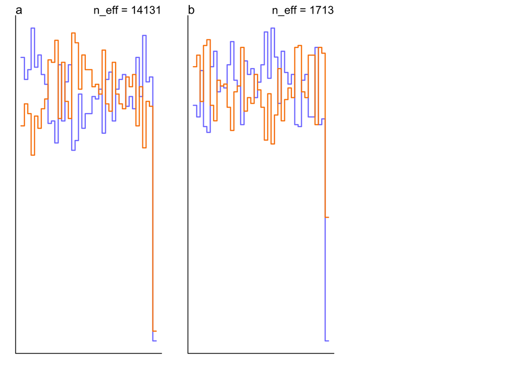

```r
trankplot(mp)
```

### Compare the samples for the parameters a and b. Can you explain the different trace plots, using what you know about the Cauchy distribution?

## 8H2. Recall the divorce rate example from Chapter 5. Repeat that analysis, using map2stan this time, fitting models m5.1, m5.2, and m5.3. Use compare to compare the models on the basis of WAIC. Explain the results.

```r
# load data and copy
#library(rethinking)
data(WaffleDivorce)
d <- WaffleDivorce
# standardize variables
d$A <- scale( d$MedianAgeMarriage )
d$D <- scale( d$Divorce )
```

```r
m5.1 <- quap(
    alist(
        D ~ dnorm( mu , sigma ) ,
        mu <- a + bA * A ,
        a ~ dnorm( 0 , 0.2 ) ,
        bA ~ dnorm( 0 , 0.5 ) ,
        sigma ~ dexp( 1 )
) , data = d )
```

```r
d$M <- scale( d$Marriage )
m5.2 <- quap(
    alist(
        D ~ dnorm( mu , sigma ) ,
        mu <- a + bM * M ,
        a ~ dnorm( 0 , 0.2 ) ,
        bM ~ dnorm( 0 , 0.5 ) ,
        sigma ~ dexp( 1 )
) , data = d )
```

```r
m5.3 <- quap(
    alist(
        D ~ dnorm( mu , sigma ) ,
        mu <- a + bM*M + bA*A ,
        a ~ dnorm( 0 , 0.2 ) ,
        bM ~ dnorm( 0 , 0.5 ) ,
        bA ~ dnorm( 0 , 0.5 ) ,
        sigma ~ dexp( 1 )
    ) , data = d )
```